# Анализ рынка недвижимости в г. Санкт-Петербург

### Общая информация о данных

```python
import pandas as pd
import matplotlib.pyplot as plt
data = pd.read_csv('https://code.s3.yandex.net/datasets/real_estate_data.csv', sep = '\t')
display(data)
data.info()
```

|  | total_images | last_price | total_area | first_day_exposition | rooms | ceiling_height | floors_total | living_area | floor | is_apartment | ... | kitchen_area | balcony | locality_name | airports_nearest | cityCenters_nearest | parks_around3000 | parks_nearest | ponds_around3000 | ponds_nearest | days_exposition |
| --- | --- | --- | --- | --- | --- | --- | --- | --- | --- | --- | --- | --- | --- | --- | --- | --- | --- | --- | --- | --- | --- |
| 0 | 20 | 13000000.0 | 108.00 | 2019-03-07T00:00:00 | 3 | 2.70 | 16.0 | 51.0 | 8 | NaN | ... | 25.00 | NaN | Санкт-Петербург | 18863.0 | 16028.0 | 1.0 | 482.0 | 2.0 | 755.0 | NaN |
| 1 | 7 | 3350000.0 | 40.40 | 2018-12-04T00:00:00 | 1 | NaN | 11.0 | 18.6 | 1 | NaN | ... | 11.00 | 2.0 | посёлок Шушары | 12817.0 | 18603.0 | 0.0 | NaN | 0.0 | NaN | 81.0 |
| 2 | 10 | 5196000.0 | 56.00 | 2015-08-20T00:00:00 | 2 | NaN | 5.0 | 34.3 | 4 | NaN | ... | 8.30 | 0.0 | Санкт-Петербург | 21741.0 | 13933.0 | 1.0 | 90.0 | 2.0 | 574.0 | 558.0 |
| 3 | 0 | 64900000.0 | 159.00 | 2015-07-24T00:00:00 | 3 | NaN | 14.0 | NaN | 9 | NaN | ... | NaN | 0.0 | Санкт-Петербург | 28098.0 | 6800.0 | 2.0 | 84.0 | 3.0 | 234.0 | 424.0 |
| 4 | 2 | 10000000.0 | 100.00 | 2018-06-19T00:00:00 | 2 | 3.03 | 14.0 | 32.0 | 13 | NaN | ... | 41.00 | NaN | Санкт-Петербург | 31856.0 | 8098.0 | 2.0 | 112.0 | 1.0 | 48.0 | 121.0 |
| ... | ... | ... | ... | ... | ... | ... | ... | ... | ... | ... | ... | ... | ... | ... | ... | ... | ... | ... | ... | ... | ... |
| 23694 | 9 | 9700000.0 | 133.81 | 2017-03-21T00:00:00 | 3 | 3.70 | 5.0 | 73.3 | 3 | NaN | ... | 13.83 | NaN | Санкт-Петербург | 24665.0 | 4232.0 | 1.0 | 796.0 | 3.0 | 381.0 | NaN |
| 23695 | 14 | 3100000.0 | 59.00 | 2018-01-15T00:00:00 | 3 | NaN | 5.0 | 38.0 | 4 | NaN | ... | 8.50 | NaN | Тосно | NaN | NaN | NaN | NaN | NaN | NaN | 45.0 |
| 23696 | 18 | 2500000.0 | 56.70 | 2018-02-11T00:00:00 | 2 | NaN | 3.0 | 29.7 | 1 | NaN | ... | NaN | NaN | село Рождествено | NaN | NaN | NaN | NaN | NaN | NaN | NaN |
| 23697 | 13 | 11475000.0 | 76.75 | 2017-03-28T00:00:00 | 2 | 3.00 | 17.0 | NaN | 12 | NaN | ... | 23.30 | 2.0 | Санкт-Петербург | 39140.0 | 10364.0 | 2.0 | 173.0 | 3.0 | 196.0 | 602.0 |
| 23698 | 4 | 1350000.0 | 32.30 | 2017-07-21T00:00:00 | 1 | 2.50 | 5.0 | 12.3 | 1 | NaN | ... | 9.00 | NaN | поселок Новый Учхоз | NaN | NaN | NaN | NaN | NaN | NaN | NaN |

23699 rows × 22 columns

```
<class 'pandas.core.frame.DataFrame'>
RangeIndex: 23699 entries, 0 to 23698
Data columns (total 22 columns):
 #   Column                Non-Null Count  Dtype
---  ------                --------------  -----
 0   total_images          23699 non-null  int64
 1   last_price            23699 non-null  float64
 2   total_area            23699 non-null  float64
 3   first_day_exposition  23699 non-null  object
 4   rooms                 23699 non-null  int64
 5   ceiling_height        14504 non-null  float64
 6   floors_total          23613 non-null  float64
 7   living_area           21796 non-null  float64
 8   floor                 23699 non-null  int64
 9   is_apartment          2775 non-null   object
 10  studio                23699 non-null  bool
 11  open_plan             23699 non-null  bool
 12  kitchen_area          21421 non-null  float64
 13  balcony               12180 non-null  float64
 14  locality_name         23650 non-null  object
 15  airports_nearest      18157 non-null  float64
 16  cityCenters_nearest   18180 non-null  float64
 17  parks_around3000      18181 non-null  float64
 18  parks_nearest         8079 non-null   float64
 19  ponds_around3000      18181 non-null  float64
 20  ponds_nearest         9110 non-null   float64
 21  days_exposition       20518 non-null  float64
dtypes: bool(2), float64(14), int64(3), object(3)
memory usage: 3.7+ MB
```

```
array([[<Axes: title={'center': 'total_images'}>,
        <Axes: title={'center': 'last_price'}>,
        <Axes: title={'center': 'total_area'}>,
        <Axes: title={'center': 'rooms'}>],
       [<Axes: title={'center': 'ceiling_height'}>,
        <Axes: title={'center': 'floors_total'}>,
        <Axes: title={'center': 'living_area'}>,
        <Axes: title={'center': 'floor'}>],
       [<Axes: title={'center': 'kitchen_area'}>,
        <Axes: title={'center': 'balcony'}>,
        <Axes: title={'center': 'airports_nearest'}>,
        <Axes: title={'center': 'cityCenters_nearest'}>],
       [<Axes: title={'center': 'parks_around3000'}>,
        <Axes: title={'center': 'parks_nearest'}>,
        <Axes: title={'center': 'ponds_around3000'}>,
        <Axes: title={'center': 'ponds_nearest'}>],
       [<Axes: title={'center': 'days_exposition'}>, <Axes: >, <Axes: >,
        <Axes: >]], dtype=object)
```

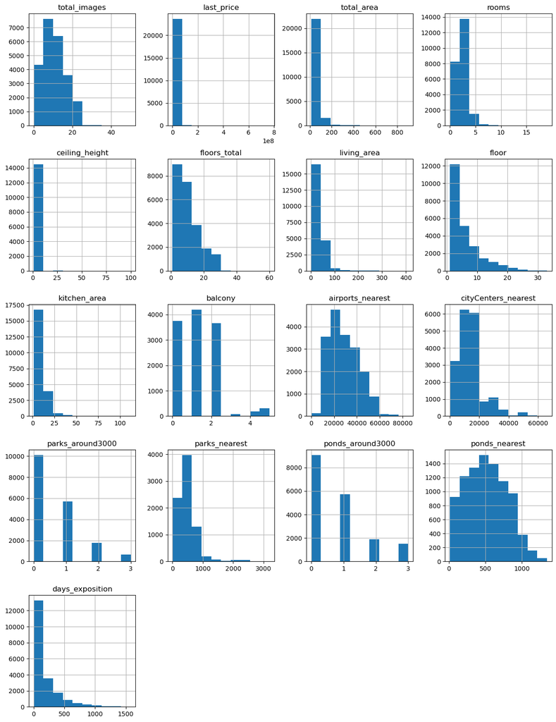

```python
data.hist(figsize=(15, 20)) #строим общую гистограмму для всех числовых столбцов таблицы
```

Вывод: В части столбцов есть пропуски в данных: ceiling_height, floors_total, living_area, is_apartment, kitchen_area, balcony, locality_name, airports_nearest, cityCenters_nearest, parks_around3000, parks_nearest, ponds_around3000, ponds_nearest, days_exposition. В части столбцов неверный тип данных: first_day_exposition - нужно изменить на datetime для удобства работы с датой. В столбцах floors_total и balcony должны быть целочисленные типы, так как они обозначают количество. В total_area, living_area, kitchen_area и rooms есть очень большие значения - нужно оценить их и понять не повлияют ли они на результат.

### Предобработка данных

Проверяем наличие пропущенных значений в столбцах таблицы:

```python
data.isna().sum()
```

```
total_images                0
last_price                  0
total_area                  0
first_day_exposition        0
rooms                       0
ceiling_height           9195
floors_total               86
living_area              1903
floor                       0
is_apartment            20924
studio                      0
open_plan                   0
kitchen_area             2278
balcony                 11519
locality_name              49
airports_nearest         5542
cityCenters_nearest      5519
parks_around3000         5518
parks_nearest           15620
ponds_around3000         5518
ponds_nearest           14589
days_exposition          3181
dtype: int64
```

В 14 столбцах присутствуют пропущенные значения.

В количестве балконов пропуски скорее всего встречаются, так у данных квартир нет балконов. Заполним такие пропуски нулями.

При заполнении информации о помещении те, чья квартира не является апартаментами, могли пропускать данный раздел, что привело к появлению Null. Целесообразно заполнить пропуски значением False.

Пропуски в высоте потолков заполняем медианным значением.

В остальных пропущенных значениях оставляем ячейки пустыми, заполнить их не представляется возможным, квартиры очень разные и заполнить средними или медианными значениями даже деля их на сегменты будет некорректно. Удалить такие строки не можем, так как их много и удаление может сильно исказить результаты анализа. Скорее всего заполняющие объявления люди не посчитали обязательным для продажи квартиры заполнение этих полей или не знали точных параметров.

Удаляем строки с пропущенными значениями в floors_total и locality_name, их отсутствие не повлияет значительно на результат, так как таких строк всего 86 и 49 соответственно.

```python
data['balcony'] = data['balcony'].fillna(0)

data['is_apartment'] = data['is_apartment'].fillna(False)

ceiling_height_median = data['ceiling_height'].median()
for ceiling_height_null in data['ceiling_height'].unique():
    data.loc[(data['ceiling_height'].isna()), 'ceiling_height'] = ceiling_height_median
data.info()

data = data.dropna(subset=['floors_total'])
data = data.dropna(subset=['locality_name'])

data.isna().sum()
```

```
<class 'pandas.core.frame.DataFrame'>
RangeIndex: 23699 entries, 0 to 23698
Data columns (total 22 columns):
 #   Column                Non-Null Count  Dtype
---  ------                --------------  -----
 0   total_images          23699 non-null  int64
 1   last_price            23699 non-null  float64
 2   total_area            23699 non-null  float64
 3   first_day_exposition  23699 non-null  object
 4   rooms                 23699 non-null  int64
 5   ceiling_height        23699 non-null  float64
 6   floors_total          23613 non-null  float64
 7   living_area           21796 non-null  float64
 8   floor                 23699 non-null  int64
 9   is_apartment          23699 non-null  bool
 10  studio                23699 non-null  bool
 11  open_plan             23699 non-null  bool
 12  kitchen_area          21421 non-null  float64
 13  balcony               23699 non-null  float64
 14  locality_name         23650 non-null  object
 15  airports_nearest      18157 non-null  float64
 16  cityCenters_nearest   18180 non-null  float64
 17  parks_around3000      18181 non-null  float64
 18  parks_nearest         8079 non-null   float64
 19  ponds_around3000      18181 non-null  float64
 20  ponds_nearest         9110 non-null   float64
 21  days_exposition       20518 non-null  float64
dtypes: bool(3), float64(14), int64(3), object(2)
memory usage: 3.5+ MB
```

```
total_images                0
last_price                  0
total_area                  0
first_day_exposition        0
rooms                       0
ceiling_height              0
floors_total                0
living_area              1865
floor                       0
is_apartment                0
studio                      0
open_plan                   0
kitchen_area             2222
balcony                     0
locality_name               0
airports_nearest         5524
cityCenters_nearest      5501
parks_around3000         5500
parks_nearest           15535
ponds_around3000         5500
ponds_nearest           14529
days_exposition          3171
dtype: int64
```

Проверяем типы данных в датафрейме

```python
data.info()
```

```
<class 'pandas.core.frame.DataFrame'>
Int64Index: 23565 entries, 0 to 23698
Data columns (total 22 columns):
 #   Column                Non-Null Count  Dtype
---  ------                --------------  -----
 0   total_images          23565 non-null  int64
 1   last_price            23565 non-null  float64
 2   total_area            23565 non-null  float64
 3   first_day_exposition  23565 non-null  object
 4   rooms                 23565 non-null  int64
 5   ceiling_height        23565 non-null  float64
 6   floors_total          23565 non-null  float64
 7   living_area           21700 non-null  float64
 8   floor                 23565 non-null  int64
 9   is_apartment          23565 non-null  bool
 10  studio                23565 non-null  bool
 11  open_plan             23565 non-null  bool
 12  kitchen_area          21343 non-null  float64
 13  balcony               23565 non-null  float64
 14  locality_name         23565 non-null  object
 15  airports_nearest      18041 non-null  float64
 16  cityCenters_nearest   18064 non-null  float64
 17  parks_around3000      18065 non-null  float64
 18  parks_nearest         8030 non-null   float64
 19  ponds_around3000      18065 non-null  float64
 20  ponds_nearest         9036 non-null   float64
 21  days_exposition       20394 non-null  float64
dtypes: bool(3), float64(14), int64(3), object(2)
memory usage: 3.7+ MB
```

В столбце first_day_exposition изменим тип на datetime для удобства работы с датой.

В столбцах floors_total и balcony изменим тип на целочисленный, так как количество этажей и балконов не может быть выражено в дробном числе.

```python
data['first_day_exposition'] = pd.to_datetime(data['first_day_exposition'], format='%Y-%m-%dT%H:%M:%S')
data['floors_total']=data['floors_total'].astype('int')
data['balcony']=data['balcony'].astype('int')
data.info()
```

```
<class 'pandas.core.frame.DataFrame'>
Int64Index: 23565 entries, 0 to 23698
Data columns (total 22 columns):
 #   Column                Non-Null Count  Dtype
---  ------                --------------  -----
 0   total_images          23565 non-null  int64
 1   last_price            23565 non-null  float64
 2   total_area            23565 non-null  float64
 3   first_day_exposition  23565 non-null  datetime64[ns]
 4   rooms                 23565 non-null  int64
 5   ceiling_height        23565 non-null  float64
 6   floors_total          23565 non-null  int64
 7   living_area           21700 non-null  float64
 8   floor                 23565 non-null  int64
 9   is_apartment          23565 non-null  bool
 10  studio                23565 non-null  bool
 11  open_plan             23565 non-null  bool
 12  kitchen_area          21343 non-null  float64
 13  balcony               23565 non-null  int64
 14  locality_name         23565 non-null  object
 15  airports_nearest      18041 non-null  float64
 16  cityCenters_nearest   18064 non-null  float64
 17  parks_around3000      18065 non-null  float64
 18  parks_nearest         8030 non-null   float64
 19  ponds_around3000      18065 non-null  float64
 20  ponds_nearest         9036 non-null   float64
 21  days_exposition       20394 non-null  float64
dtypes: bool(3), datetime64[ns](1), float64(12), int64(5), object(1)
memory usage: 3.7+ MB
```

Проверяем наличие дубликаов в датафрейме

```python
data.duplicated().sum()
```

```
0
```

Изучаем столбец с названиями и удаляем неявные дубликаты

```python
data['locality_name'].sort_values().unique()
```

```
array(['Бокситогорск', 'Волосово', 'Волхов', 'Всеволожск', 'Выборг',
       'Высоцк', 'Гатчина', 'Зеленогорск', 'Ивангород', 'Каменногорск',
       'Кингисепп', 'Кириши', 'Кировск', 'Колпино', 'Коммунар',
       'Красное Село', 'Кронштадт', 'Кудрово', 'Лодейное Поле',
       'Ломоносов', 'Луга', 'Любань', 'Мурино', 'Никольское',
       'Новая Ладога', 'Отрадное', 'Павловск', 'Петергоф', 'Пикалёво',
       'Подпорожье', 'Приморск', 'Приозерск', 'Пушкин', 'Санкт-Петербург',
       'Светогорск', 'Сертолово', 'Сестрорецк', 'Сланцы', 'Сосновый Бор',
       'Сясьстрой', 'Тихвин', 'Тосно', 'Шлиссельбург',
       'городской поселок Большая Ижора', 'городской поселок Янино-1',
       'городской посёлок Будогощь', 'городской посёлок Виллози',
       'городской посёлок Лесогорский', 'городской посёлок Мга',
       'городской посёлок Назия', 'городской посёлок Новоселье',
       'городской посёлок Павлово', 'городской посёлок Рощино',
       'городской посёлок Свирьстрой', 'городской посёлок Советский',
       'городской посёлок Фёдоровское', 'городской посёлок Янино-1',
       'деревня Агалатово', 'деревня Аро', 'деревня Батово',
       'деревня Бегуницы', 'деревня Белогорка', 'деревня Большая Вруда',
       'деревня Большая Пустомержа', 'деревня Большие Колпаны',
       'деревня Большое Рейзино', 'деревня Большой Сабск', 'деревня Бор',
       'деревня Борисова Грива', 'деревня Ваганово', 'деревня Вартемяги',
       'деревня Вахнова Кара', 'деревня Выскатка', 'деревня Гарболово',
       'деревня Глинка', 'деревня Горбунки', 'деревня Гостилицы',
       'деревня Заклинье', 'деревня Заневка', 'деревня Зимитицы',
       'деревня Извара', 'деревня Иссад', 'деревня Калитино',
       'деревня Кальтино', 'деревня Камышовка', 'деревня Каськово',
       'деревня Келози', 'деревня Кипень', 'деревня Кисельня',
       'деревня Колтуши', 'деревня Коркино', 'деревня Котлы',
       'деревня Кривко', 'деревня Кудрово', 'деревня Кузьмолово',
       'деревня Курковицы', 'деревня Куровицы', 'деревня Куттузи',
       'деревня Лаврики', 'деревня Лаголово', 'деревня Лампово',
       'деревня Лесколово', 'деревня Лопухинка', 'деревня Лупполово',
       'деревня Малая Романовка', 'деревня Малое Верево',
       'деревня Малое Карлино', 'деревня Малые Колпаны',
       'деревня Мануйлово', 'деревня Меньково', 'деревня Мины',
       'деревня Мистолово', 'деревня Ненимяки', 'деревня Нижние Осельки',
       'деревня Нижняя', 'деревня Низино', 'деревня Новое Девяткино',
       'деревня Новолисино', 'деревня Нурма', 'деревня Оржицы',
       'деревня Парицы', 'деревня Пельгора', 'деревня Пеники',
       'деревня Пижма', 'деревня Пикколово', 'деревня Пудомяги',
```

[output cut: 96 more lines]

```
       'посёлок городского типа Тайцы', 'посёлок городского типа Токсово',
       'посёлок городского типа Ульяновка',
       'посёлок городского типа Форносово',
       'посёлок городского типа имени Морозова',
       'посёлок городского типа имени Свердлова',
       'посёлок при железнодорожной станции Вещево',
       'посёлок при железнодорожной станции Приветнинское',
       'посёлок станции Громово', 'посёлок станции Свирь',
       'садоводческое некоммерческое товарищество Лесная Поляна',
       'садовое товарищество Новая Ропша',
       'садовое товарищество Приладожский', 'садовое товарищество Рахья',
       'садовое товарищество Садко', 'село Копорье', 'село Никольское',
       'село Павлово', 'село Паша', 'село Путилово', 'село Рождествено',
       'село Русско-Высоцкое', 'село Старая Ладога', 'село Шум'],
      dtype=object)
```

Избавляемся от длинных наименований и буквы "ё", для уменьшения повторов в названиях населенных пунктов:

```python
data['locality_name'] = data['locality_name'].str.replace('ё', 'е')
data['locality_name'] = data['locality_name'].str.replace('поселок городского типа', 'пгт')
data['locality_name'] = data['locality_name'].str.replace('деревня', 'д.')
data['locality_name'] = data['locality_name'].str.replace('поселок', 'п.')
data['locality_name'].sort_values().unique()
```

```
array(['Бокситогорск', 'Волосово', 'Волхов', 'Всеволожск', 'Выборг',
       'Высоцк', 'Гатчина', 'Зеленогорск', 'Ивангород', 'Каменногорск',
       'Кингисепп', 'Кириши', 'Кировск', 'Колпино', 'Коммунар',
       'Красное Село', 'Кронштадт', 'Кудрово', 'Лодейное Поле',
       'Ломоносов', 'Луга', 'Любань', 'Мурино', 'Никольское',
       'Новая Ладога', 'Отрадное', 'Павловск', 'Петергоф', 'Пикалево',
       'Подпорожье', 'Приморск', 'Приозерск', 'Пушкин', 'Санкт-Петербург',
       'Светогорск', 'Сертолово', 'Сестрорецк', 'Сланцы', 'Сосновый Бор',
       'Сясьстрой', 'Тихвин', 'Тосно', 'Шлиссельбург',
       'городской п. Большая Ижора', 'городской п. Будогощь',
       'городской п. Виллози', 'городской п. Лесогорский',
       'городской п. Мга', 'городской п. Назия', 'городской п. Новоселье',
       'городской п. Павлово', 'городской п. Рощино',
       'городской п. Свирьстрой', 'городской п. Советский',
       'городской п. Федоровское', 'городской п. Янино-1', 'д. Агалатово',
       'д. Аро', 'д. Батово', 'д. Бегуницы', 'д. Белогорка',
       'д. Большая Вруда', 'д. Большая Пустомержа', 'д. Большие Колпаны',
       'д. Большое Рейзино', 'д. Большой Сабск', 'д. Бор',
       'д. Борисова Грива', 'д. Ваганово', 'д. Вартемяги',
       'д. Вахнова Кара', 'д. Выскатка', 'д. Гарболово', 'д. Глинка',
       'д. Горбунки', 'д. Гостилицы', 'д. Заклинье', 'д. Заневка',
       'д. Зимитицы', 'д. Извара', 'д. Иссад', 'д. Калитино',
       'д. Кальтино', 'д. Камышовка', 'д. Каськово', 'д. Келози',
       'д. Кипень', 'д. Кисельня', 'д. Колтуши', 'д. Коркино', 'д. Котлы',
       'д. Кривко', 'д. Кудрово', 'д. Кузьмолово', 'д. Курковицы',
       'д. Куровицы', 'д. Куттузи', 'д. Лаврики', 'д. Лаголово',
       'д. Лампово', 'д. Лесколово', 'д. Лопухинка', 'д. Лупполово',
       'д. Малая Романовка', 'д. Малое Верево', 'д. Малое Карлино',
       'д. Малые Колпаны', 'д. Мануйлово', 'д. Меньково', 'д. Мины',
       'д. Мистолово', 'д. Ненимяки', 'д. Нижние Осельки', 'д. Нижняя',
       'д. Низино', 'д. Новое Девяткино', 'д. Новолисино', 'д. Нурма',
       'д. Оржицы', 'д. Парицы', 'д. Пельгора', 'д. Пеники', 'д. Пижма',
       'д. Пикколово', 'д. Пудомяги', 'д. Пустынка', 'д. Пчева',
       'д. Рабитицы', 'д. Разбегаево', 'д. Раздолье', 'д. Разметелево',
       'д. Рапполово', 'д. Реброво', 'д. Русско', 'д. Сижно',
       'д. Снегиревка', 'д. Старая', 'д. Старая Пустошь',
       'д. Старое Хинколово', 'д. Старополье', 'д. Старосиверская',
       'д. Старые Бегуницы', 'д. Суоранда', 'д. Сяськелево',
       'д. Тарасово', 'д. Терпилицы', 'д. Тихковицы', 'д. Тойворово',
       'д. Торосово', 'д. Торошковичи', 'д. Трубников Бор',
```

[output cut: 40 more lines]

```
       'пгт Вознесенье', 'пгт Вырица', 'пгт Дружная Горка',
       'пгт Дубровка', 'пгт Ефимовский', 'пгт Кондратьево',
       'пгт Красный Бор', 'пгт Кузнечное', 'пгт Кузьмоловский',
       'пгт Лебяжье', 'пгт Лесогорский', 'пгт Мга', 'пгт Назия',
       'пгт Никольский', 'пгт Павлово', 'пгт Приладожский', 'пгт Рахья',
       'пгт Рощино', 'пгт Рябово', 'пгт Сиверский', 'пгт Синявино',
       'пгт Советский', 'пгт Тайцы', 'пгт Токсово', 'пгт Ульяновка',
       'пгт Форносово', 'пгт имени Морозова', 'пгт имени Свердлова',
       'садоводческое некоммерческое товарищество Лесная Поляна',
       'садовое товарищество Новая Ропша',
       'садовое товарищество Приладожский', 'садовое товарищество Рахья',
       'садовое товарищество Садко', 'село Копорье', 'село Никольское',
       'село Павлово', 'село Паша', 'село Путилово', 'село Рождествено',
       'село Русско-Высоцкое', 'село Старая Ладога', 'село Шум'],
      dtype=object)
```

Заменяем видимые предположительные дубликаты в названиях:

```python
data['locality_name'] = data['locality_name'].str.replace('п. при железнодорожной станции Вещево', \
                                                          'п. станции Вещево', regex=True)
data['locality_name'] = data['locality_name'].str.replace('п. при железнодорожной станции Приветнинское', \
                                                          'п. станции Приветнинское', regex=True)
data['locality_name'] = data['locality_name'].str.replace('коттеджный п. Лесное', 'п. Лесное', regex=True)
```

Находим аномалии в столбце ceiling_height, если значения больше 10, разделим их на 10, так как скорее всего это опечатка.

```python
print(data['ceiling_height'].unique())
data.loc[data['ceiling_height'] > 10, 'ceiling_height'] = data['ceiling_height']/10
```

```
[  2.7    2.65   3.03   2.5    2.67   2.56   3.05   2.75   2.6    2.9
   2.8    2.55   3.     3.2    2.61   3.25   3.45   2.77   2.85   2.64
   2.57   4.15   3.5    3.3    2.71   4.     2.47   2.73   2.84   3.1
   2.34   3.4    3.06   2.72   2.54   2.51   2.78   2.76  25.     2.58
   3.7    2.52   5.2    2.87   2.66   2.59   2.     2.45   3.6    2.92
   3.11   3.13   3.8    3.15   3.55   3.16   3.62   3.12   2.53   2.74
   2.96   2.46   5.3    5.     2.79   2.95   4.06   2.94   3.82   3.54
   3.53   2.83   4.7    2.4    3.38   3.01   5.6    3.65   3.9    3.18
   3.35   2.3    3.57   2.48   2.62   2.82   3.98   2.63   3.83   3.52
   3.95   3.75   2.88   3.67   3.87   3.66   3.85   3.86   4.19   3.24
   4.8    4.5    4.2    3.36  32.     3.08   3.68   3.07   3.37   3.09
   8.     3.26   3.34   2.81   3.44   2.97   3.14   4.37   2.68   3.22
   3.27  27.     4.1    2.93   3.46  24.     3.47   3.33   3.63   3.32
  26.     1.2    8.3    2.98   2.86   3.17   4.4    3.28   3.04   4.45
   5.5    3.84   3.23   3.02   3.21   3.43   3.78   4.3    3.39   2.69
   3.31   4.65   3.56   2.2    3.51   3.93   3.42   2.99   3.49  14.
   4.14   2.91   3.88   1.75   4.25   3.29  20.     2.25   3.76   3.69
   6.    22.6    2.89   3.58   5.8   27.5    2.49   4.9    3.48  10.3
   1.   100.     3.59]
```

Ищем аномалии в других столбцах.

```python
data['rooms'].unique()
```

```
array([ 3,  1,  2,  4,  5,  6,  0,  7, 11,  8, 14, 10, 15,  9, 19, 16, 12])
```

```python
data[(data['rooms']>10)]
```

|  | total_images | last_price | total_area | first_day_exposition | rooms | ceiling_height | floors_total | living_area | floor | is_apartment | ... | kitchen_area | balcony | locality_name | airports_nearest | cityCenters_nearest | parks_around3000 | parks_nearest | ponds_around3000 | ponds_nearest | days_exposition |
| --- | --- | --- | --- | --- | --- | --- | --- | --- | --- | --- | --- | --- | --- | --- | --- | --- | --- | --- | --- | --- | --- |
| 648 | 3 | 17500000.0 | 183.7 | 2018-07-01 | 11 | 3.40 | 7 | 138.8 | 7 | False | ... | 13.3 | 0 | Санкт-Петербург | 23606.0 | 3148.0 | 0.0 | NaN | 0.0 | NaN | NaN |
| 866 | 5 | 25000000.0 | 363.0 | 2017-12-23 | 14 | 3.16 | 5 | 222.0 | 4 | False | ... | 16.6 | 0 | Санкт-Петербург | 38076.0 | 7950.0 | 0.0 | NaN | 2.0 | 435.0 | 418.0 |
| 5358 | 20 | 65000000.0 | 590.0 | 2019-02-14 | 15 | 3.50 | 6 | 409.0 | 3 | False | ... | 100.0 | 0 | Санкт-Петербург | 24447.0 | 4666.0 | 1.0 | 767.0 | 0.0 | NaN | 14.0 |
| 9688 | 8 | 33000000.0 | 194.1 | 2017-02-07 | 11 | 3.43 | 5 | 129.0 | 2 | False | ... | 11.9 | 0 | Санкт-Петербург | 21469.0 | 1015.0 | 1.0 | 686.0 | 2.0 | 66.0 | 813.0 |
| 14498 | 6 | 32250000.0 | 374.6 | 2018-06-09 | 19 | 2.65 | 5 | 264.5 | 2 | False | ... | 27.6 | 0 | Санкт-Петербург | 19497.0 | 3574.0 | 0.0 | NaN | 2.0 | 548.0 | 114.0 |
| 18848 | 6 | 28500000.0 | 270.0 | 2015-03-02 | 16 | 3.00 | 4 | 180.0 | 4 | False | ... | 13.0 | 1 | Санкт-Петербург | 23575.0 | 4142.0 | 1.0 | 516.0 | 0.0 | NaN | 1365.0 |
| 19540 | 8 | 420000000.0 | 900.0 | 2017-12-06 | 12 | 2.80 | 25 | 409.7 | 25 | False | ... | 112.0 | 0 | Санкт-Петербург | 30706.0 | 7877.0 | 0.0 | NaN | 2.0 | 318.0 | 106.0 |
| 20829 | 6 | 28659000.0 | 245.4 | 2016-03-31 | 14 | 2.65 | 4 | 168.3 | 2 | False | ... | 25.9 | 0 | Санкт-Петербург | 21104.0 | 2054.0 | 3.0 | 541.0 | 2.0 | 118.0 | 95.0 |

8 rows × 22 columns

```python
print (data['living_area'].sort_values().unique())
print ('среднее:', data['living_area'].mean().round())
print ('медиана:', data['living_area'].median())
```

```
[  2.    3.    5.  ... 409.  409.7   nan]
среднее: 34.0
медиана: 30.0
```

В размерах жилого помещения есть очень большие значения, но между средним и медианой разница не значительно отличается.

Посмотрим подробнее какие значения есть в столбцах со стоимостью квартиры и общей площадью

```python
print (data['last_price'].sort_values().unique())
print ('среднее:', data['last_price'].mean().round())
print ('медиана:', data['last_price'].median())
data.sort_values('last_price', ascending = False).head(20)
```

```
[1.219e+04 4.300e+05 4.400e+05 ... 4.013e+08 4.200e+08 7.630e+08]
среднее: 6540058.0
медиана: 4646000.0
```

|  | total_images | last_price | total_area | first_day_exposition | rooms | ceiling_height | floors_total | living_area | floor | is_apartment | ... | kitchen_area | balcony | locality_name | airports_nearest | cityCenters_nearest | parks_around3000 | parks_nearest | ponds_around3000 | ponds_nearest | days_exposition |
| --- | --- | --- | --- | --- | --- | --- | --- | --- | --- | --- | --- | --- | --- | --- | --- | --- | --- | --- | --- | --- | --- |
| 12971 | 19 | 763000000.0 | 400.0 | 2017-09-30 | 7 | 2.65 | 10 | 250.0 | 10 | False | ... | NaN | 2 | Санкт-Петербург | 25108.0 | 3956.0 | 1.0 | 530.0 | 3.0 | 756.0 | 33.0 |
| 19540 | 8 | 420000000.0 | 900.0 | 2017-12-06 | 12 | 2.80 | 25 | 409.7 | 25 | False | ... | 112.0 | 0 | Санкт-Петербург | 30706.0 | 7877.0 | 0.0 | NaN | 2.0 | 318.0 | 106.0 |
| 14706 | 15 | 401300000.0 | 401.0 | 2016-02-20 | 5 | 2.65 | 9 | 204.0 | 9 | False | ... | 24.0 | 3 | Санкт-Петербург | 21912.0 | 2389.0 | 1.0 | 545.0 | 1.0 | 478.0 | 393.0 |
| 1436 | 19 | 330000000.0 | 190.0 | 2018-04-04 | 3 | 3.50 | 7 | 95.0 | 5 | False | ... | 40.0 | 0 | Санкт-Петербург | 23011.0 | 1197.0 | 3.0 | 519.0 | 3.0 | 285.0 | 233.0 |
| 15651 | 20 | 300000000.0 | 618.0 | 2017-12-18 | 7 | 3.40 | 7 | 258.0 | 5 | False | ... | 70.0 | 0 | Санкт-Петербург | 32440.0 | 5297.0 | 0.0 | NaN | 2.0 | 198.0 | 111.0 |
| 22831 | 18 | 289238400.0 | 187.5 | 2019-03-19 | 2 | 3.37 | 6 | 63.7 | 6 | False | ... | 30.2 | 0 | Санкт-Петербург | 22494.0 | 1073.0 | 3.0 | 386.0 | 3.0 | 188.0 | NaN |
| 16461 | 17 | 245000000.0 | 285.7 | 2017-04-10 | 6 | 3.35 | 7 | 182.8 | 4 | False | ... | 29.8 | 0 | Санкт-Петербург | 33143.0 | 6235.0 | 3.0 | 400.0 | 3.0 | 140.0 | 249.0 |
| 13749 | 7 | 240000000.0 | 410.0 | 2017-04-01 | 6 | 3.40 | 7 | 218.0 | 7 | False | ... | 40.0 | 0 | Санкт-Петербург | 32440.0 | 5297.0 | 0.0 | NaN | 2.0 | 198.0 | 199.0 |
| 5893 | 3 | 230000000.0 | 500.0 | 2017-05-31 | 6 | 2.65 | 7 | NaN | 7 | False | ... | 40.0 | 0 | Санкт-Петербург | 32440.0 | 5297.0 | 0.0 | NaN | 2.0 | 198.0 | 50.0 |
| 8900 | 13 | 190870000.0 | 268.0 | 2016-03-25 | 3 | 2.65 | 8 | 132.0 | 7 | False | ... | 40.0 | 0 | Санкт-Петербург | 32440.0 | 5297.0 | 0.0 | NaN | 2.0 | 198.0 | 901.0 |
| 19865 | 20 | 180000000.0 | 347.0 | 2015-01-21 | 8 | 3.90 | 6 | 260.0 | 3 | False | ... | 45.0 | 0 | Санкт-Петербург | 23962.0 | 3794.0 | 2.0 | 537.0 | 3.0 | 501.0 | 834.0 |
| 19155 | 20 | 160000000.0 | 243.0 | 2018-11-12 | 5 | 2.65 | 5 | 145.0 | 4 | False | ... | 33.0 | 0 | Санкт-Петербург | 22640.0 | 555.0 | 3.0 | 285.0 | 1.0 | 200.0 | 18.0 |
| 2536 | 16 | 159984000.0 | 242.4 | 2015-08-27 | 4 | 3.85 | 9 | 131.0 | 7 | False | ... | 20.0 | 0 | Санкт-Петербург | 21946.0 | 2242.0 | 1.0 | 679.0 | 1.0 | 227.0 | 501.0 |
| 16495 | 12 | 159000000.0 | 260.0 | 2017-04-04 | 4 | 2.65 | 5 | 180.0 | 4 | False | ... | 30.0 | 2 | Санкт-Петербург | 21740.0 | 436.0 | 2.0 | 138.0 | 3.0 | 620.0 | 178.0 |
| 1026 | 20 | 155000000.0 | 310.0 | 2018-10-12 | 5 | 5.30 | 3 | 190.0 | 3 | False | ... | 63.0 | 2 | Санкт-Петербург | 24899.0 | 4785.0 | 0.0 | NaN | 1.0 | 603.0 | NaN |
| 7857 | 11 | 150000000.0 | 230.0 | 2017-10-25 | 8 | 2.65 | 8 | 220.0 | 8 | False | ... | NaN | 0 | Санкт-Петербург | 25525.0 | 5845.0 | 2.0 | 116.0 | 0.0 | NaN | 135.0 |
| 15016 | 8 | 150000000.0 | 500.0 | 2016-01-13 | 4 | 3.20 | 7 | NaN | 7 | False | ... | NaN | 0 | Санкт-Петербург | 33058.0 | 6150.0 | 3.0 | 209.0 | 3.0 | 531.0 | 303.0 |
| 22229 | 16 | 148000000.0 | 256.0 | 2016-03-16 | 5 | 2.65 | 6 | 179.0 | 5 | False | ... | 36.0 | 0 | Санкт-Петербург | 24072.0 | 3639.0 | 2.0 | 727.0 | 3.0 | 462.0 | 233.0 |
| 12674 | 16 | 140000000.0 | 241.0 | 2015-07-24 | 5 | 3.00 | 5 | NaN | 4 | False | ... | NaN | 0 | Санкт-Петербург | 23512.0 | 3503.0 | 3.0 | 413.0 | 3.0 | 83.0 | 399.0 |
| 12859 | 20 | 140000000.0 | 631.2 | 2019-04-09 | 7 | 3.90 | 4 | 322.3 | 4 | False | ... | 19.5 | 1 | Санкт-Петербург | 25707.0 | 4972.0 | 0.0 | NaN | 2.0 | 210.0 | NaN |

20 rows × 22 columns

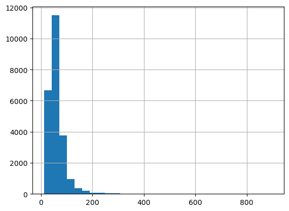

```python
data2 = pd.read_csv('https://code.s3.yandex.net/datasets/real_estate_data.csv', sep='\t')
(data2['total_area']).hist(bins=30);
```

```
(100000.0, 300000000.0)
```

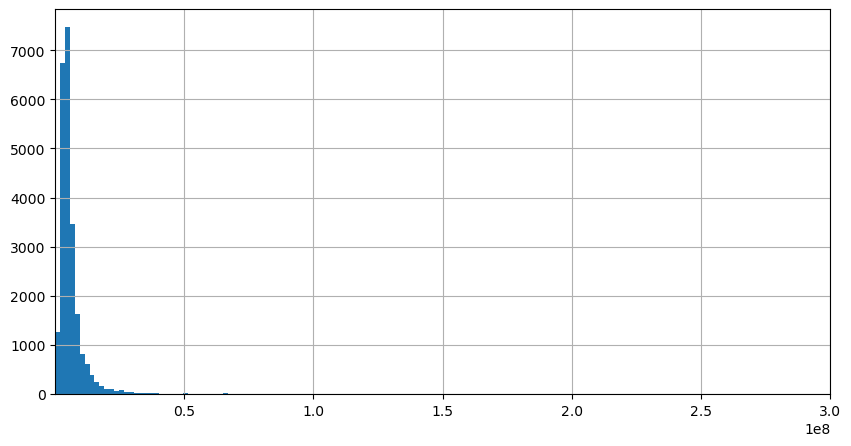

```python
data['last_price'].hist(bins=400, figsize = (10,5))
plt.xlim(100000,300000000)
```

Удаляем строки с общей площадью больше 200 м, стоимостью более 50 млн и количеством комнат больше 10.

```python
data = data[(data.total_area <= 200) & (data.last_price <= 50000000) & (data.rooms < 10)]
data.shape[0]/data2.shape[0]
```

```
0.9826153002236381
```

В результате предобработки отброшено около 2% данных, это значит, что результат не исказится значительно.

### Посчитаем и добавим в таблицу:

- цену одного квадратного метра price_for_m,
- день недели публикации объявления published_day,
- месяц публикации объявления published_month,
- год публикации объявления published_year,
- тип этажа квартиры (значения — «первый», «последний», «другой»);
- расстояние до центра города в километрах cityCenters_nearest_km.

```python
data['price_for_m'] = data['last_price']/data['total_area']
data['published_day'] = data['first_day_exposition'].dt.weekday
data['published_month'] = pd.DatetimeIndex(data['first_day_exposition']).month
data['published_year'] = pd.DatetimeIndex(data['first_day_exposition']).year

data['floors_type']=''
data.loc[data['floor'] == 1, 'floors_type'] = 'первый'
data.loc[(data['floors_total'] == data['floor']) & (data['floors_total'] != 1), 'floors_type'] = 'последний'
data.loc[data['floors_type'] =='', 'floors_type'] = 'другой'

data['cityCenters_nearest_km'] = round(data['cityCenters_nearest']/1000)

data
```

|  | total_images | last_price | total_area | first_day_exposition | rooms | ceiling_height | floors_total | living_area | floor | is_apartment | ... | parks_nearest | ponds_around3000 | ponds_nearest | days_exposition | price_for_m | published_day | published_month | published_year | floors_type | cityCenters_nearest_km |
| --- | --- | --- | --- | --- | --- | --- | --- | --- | --- | --- | --- | --- | --- | --- | --- | --- | --- | --- | --- | --- | --- |
| 0 | 20 | 13000000.0 | 108.00 | 2019-03-07 | 3 | 2.70 | 16 | 51.0 | 8 | False | ... | 482.0 | 2.0 | 755.0 | NaN | 120370.370370 | 3 | 3 | 2019 | другой | 16.0 |
| 1 | 7 | 3350000.0 | 40.40 | 2018-12-04 | 1 | 2.65 | 11 | 18.6 | 1 | False | ... | NaN | 0.0 | NaN | 81.0 | 82920.792079 | 1 | 12 | 2018 | первый | 19.0 |
| 2 | 10 | 5196000.0 | 56.00 | 2015-08-20 | 2 | 2.65 | 5 | 34.3 | 4 | False | ... | 90.0 | 2.0 | 574.0 | 558.0 | 92785.714286 | 3 | 8 | 2015 | другой | 14.0 |
| 4 | 2 | 10000000.0 | 100.00 | 2018-06-19 | 2 | 3.03 | 14 | 32.0 | 13 | False | ... | 112.0 | 1.0 | 48.0 | 121.0 | 100000.000000 | 1 | 6 | 2018 | другой | 8.0 |
| 5 | 10 | 2890000.0 | 30.40 | 2018-09-10 | 1 | 2.65 | 12 | 14.4 | 5 | False | ... | NaN | NaN | NaN | 55.0 | 95065.789474 | 0 | 9 | 2018 | другой | NaN |
| ... | ... | ... | ... | ... | ... | ... | ... | ... | ... | ... | ... | ... | ... | ... | ... | ... | ... | ... | ... | ... | ... |
| 23694 | 9 | 9700000.0 | 133.81 | 2017-03-21 | 3 | 3.70 | 5 | 73.3 | 3 | False | ... | 796.0 | 3.0 | 381.0 | NaN | 72490.845228 | 1 | 3 | 2017 | другой | 4.0 |
| 23695 | 14 | 3100000.0 | 59.00 | 2018-01-15 | 3 | 2.65 | 5 | 38.0 | 4 | False | ... | NaN | NaN | NaN | 45.0 | 52542.372881 | 0 | 1 | 2018 | другой | NaN |
| 23696 | 18 | 2500000.0 | 56.70 | 2018-02-11 | 2 | 2.65 | 3 | 29.7 | 1 | False | ... | NaN | NaN | NaN | NaN | 44091.710758 | 6 | 2 | 2018 | первый | NaN |
| 23697 | 13 | 11475000.0 | 76.75 | 2017-03-28 | 2 | 3.00 | 17 | NaN | 12 | False | ... | 173.0 | 3.0 | 196.0 | 602.0 | 149511.400651 | 1 | 3 | 2017 | другой | 10.0 |
| 23698 | 4 | 1350000.0 | 32.30 | 2017-07-21 | 1 | 2.50 | 5 | 12.3 | 1 | False | ... | NaN | NaN | NaN | NaN | 41795.665635 | 4 | 7 | 2017 | первый | NaN |

23287 rows × 28 columns

### Исследовательский анализ данных

**Изучим различные параметры объектов:**

```
count    23287.000000
mean        57.925613
std         26.082858
min         12.000000
25%         40.000000
50%         51.600000
75%         68.500000
max        200.000000
Name: total_area, dtype: float64
```

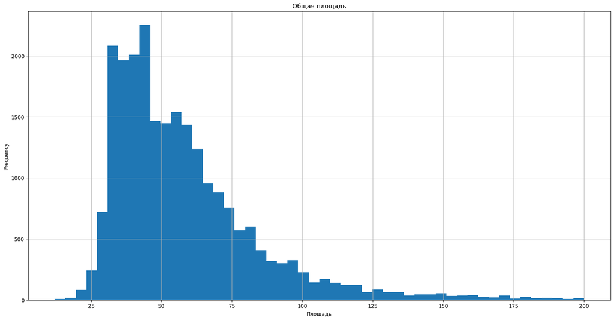

```python
data['total_area'].hist(bins=50, figsize = (20,10))
plt.title("Общая площадь")
plt.xlabel("Площадь")
plt.ylabel("Frequency")
data['total_area'].describe()
```

Большинство квартир площадью до 75 м, причем максимальное количество сосредоточено в промежутке от 40 до 50 м.

```
count    21455.000000
mean        33.137254
std         17.176026
min          2.000000
25%         18.560000
50%         30.000000
75%         42.000000
max        164.700000
Name: living_area, dtype: float64
```

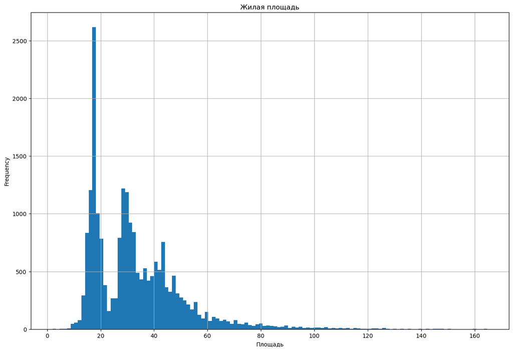

```python
data['living_area'].hist(bins=120, figsize = (15,10))
plt.title("Жилая площадь")
plt.xlabel("Площадь")
plt.ylabel("Frequency")
data['living_area'].describe()
```

Большинство квартир имеют жилую площадь от 13 до 47 м, при этом наблюдается провал по количеству квартир в промежутке от 20 до 24 м.

```
count    21099.000000
mean        10.336221
std          5.196552
min          1.300000
25%          7.000000
50%          9.000000
75%         11.900000
max         75.000000
Name: kitchen_area, dtype: float64
```

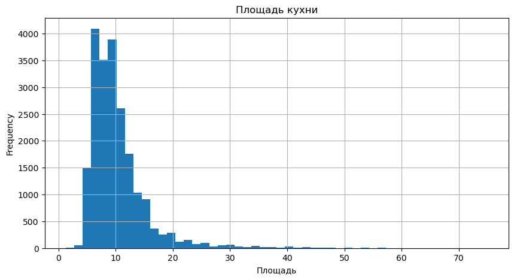

```python
data['kitchen_area'].hist(bins=50, figsize = (10,5))
plt.title("Площадь кухни")
plt.xlabel("Площадь")
plt.ylabel("Frequency")
data['kitchen_area'].describe()
```

Большинство кухонь имеет площадь от 5 до 13 м.

```
count    23287.000000
mean         5.860542
std          4.629933
min          0.012190
25%          3.400000
50%          4.600000
75%          6.650000
max         50.000000
Name: last_price, dtype: float64
```

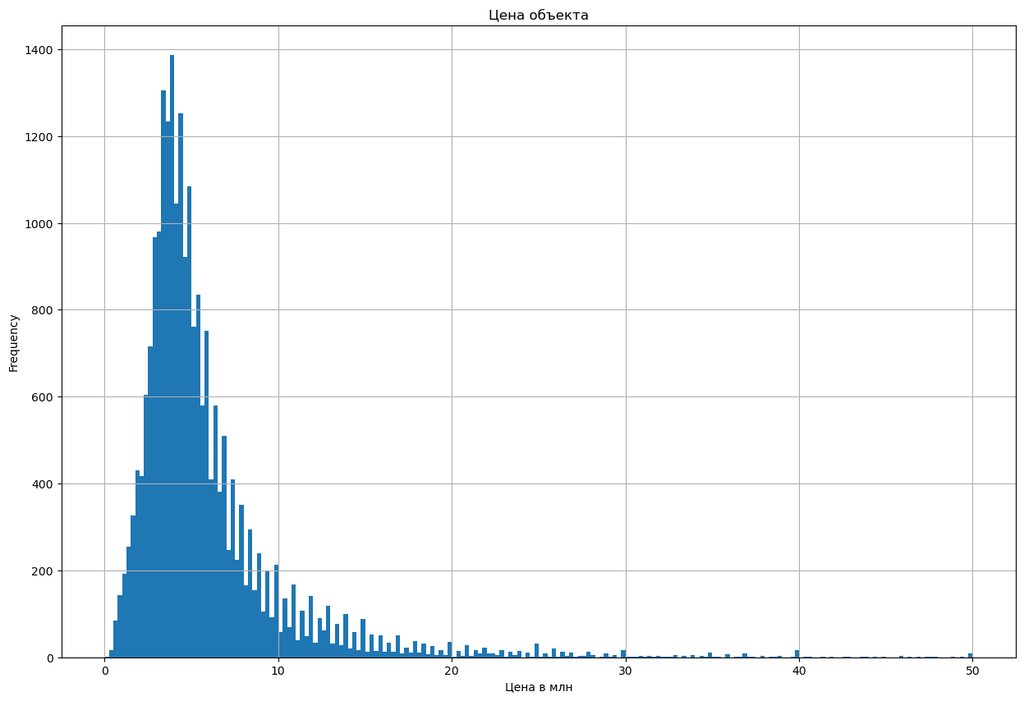

```python
data['last_price'] = data['last_price']/1000000
data['last_price'].hist(bins=200, figsize = (15,10))

plt.title("Цена объекта")
plt.xlabel("Цена в млн")
plt.ylabel("Frequency")
data['last_price'].describe()
```

Подавляющая часть квартир от 3,4 до 6,8 млн, но есть выбросы со слишком низкими и высокими ценами, сохраненными для приемлемого искажения результатов анализа.

```
count    23287.000000
mean         2.030919
std          0.990458
min          0.000000
25%          1.000000
50%          2.000000
75%          3.000000
max          8.000000
Name: rooms, dtype: float64
```

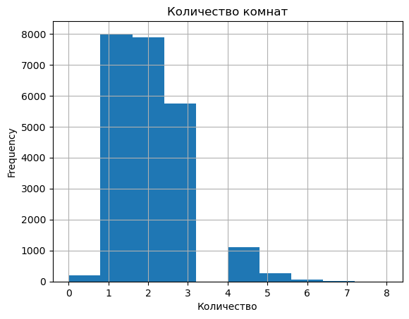

```python
data['rooms'].hist(bins=10)
plt.title("Количество комнат")
plt.xlabel("Количество")
plt.ylabel("Frequency")
data['rooms'].describe()
```

Большинство квартир имеют от 1 до 3 комнат

```python
data['rooms'].value_counts()[0]
```

```
193
```

У 193 квартир в количестве комнат проставлено значение 0.

```
count    23287.000000
mean         2.692519
std          0.226160
min          1.000000
25%          2.600000
50%          2.650000
75%          2.700000
max         10.000000
Name: ceiling_height, dtype: float64
```

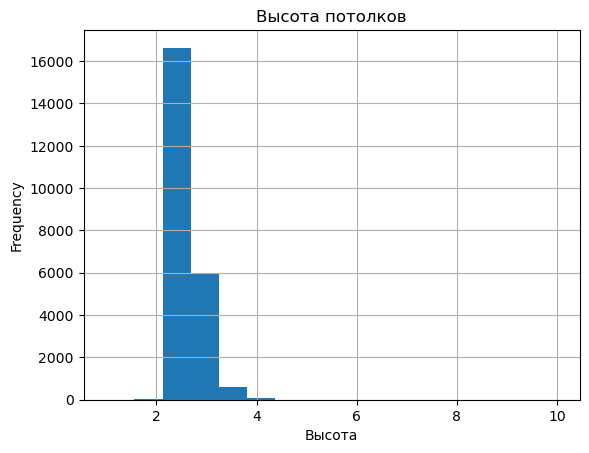

```python
data['ceiling_height'].hist(bins=16)
plt.title("Высота потолков")
plt.xlabel("Высота")
plt.ylabel("Frequency")
data['ceiling_height'].describe()
```

Большинство квартир имеет потолки от 2 до 2,8 м.

```
count    23287.000000
mean         5.888951
std          4.884120
min          1.000000
25%          2.000000
50%          4.000000
75%          8.000000
max         33.000000
Name: floor, dtype: float64
```

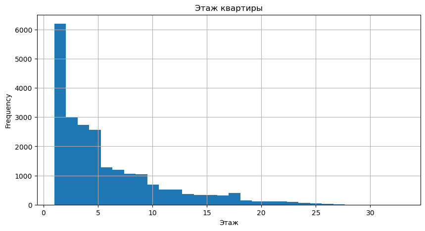

```python
data['floor'].hist(bins=30, figsize = (10,5))
plt.title("Этаж квартиры")
plt.xlabel("Этаж")
plt.ylabel("Frequency")
data['floor'].describe()
```

Большинство квартир на продажу расположены на нижних этажах (до 5 включительно)

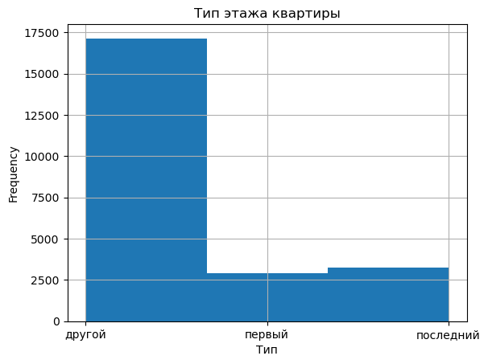

```python
data['floors_type'].hist(bins = 3)
plt.title("Тип этажа квартиры")
plt.xlabel("Тип")
plt.ylabel("Frequency")
```

При этом подавляющее большинство не на первом и не на последнем этаже.

```
count    23287.000000
mean        10.722850
std          6.607859
min          1.000000
25%          5.000000
50%          9.000000
75%         16.000000
max         60.000000
Name: floors_total, dtype: float64
```

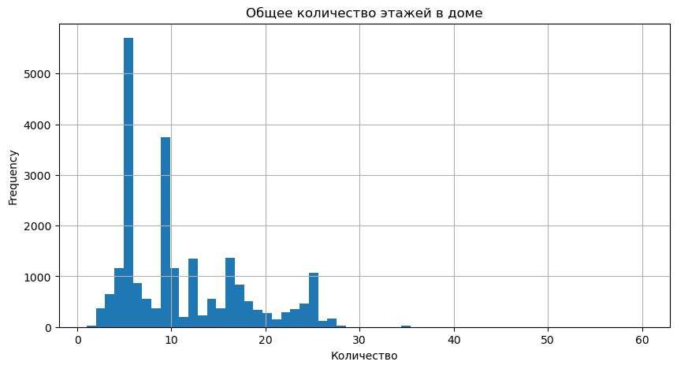

```python
data['floors_total'].hist(bins=60, figsize = (10,5))
plt.title("Общее количество этажей в доме")
plt.xlabel("Количество")
plt.ylabel("Frequency")
data['floors_total'].describe()
```

Подавляющее большинство квартир расположено в домах невысокой этажности (5 и 9 этажей).

```
count    17791.000000
mean     14308.268226
std       8596.019548
min        181.000000
25%       9486.500000
50%      13168.000000
75%      16329.000000
max      65968.000000
Name: cityCenters_nearest, dtype: float64
```

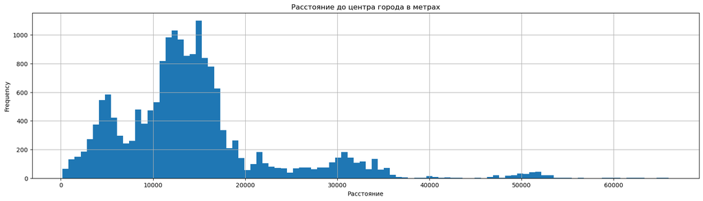

```python
data['cityCenters_nearest'].hist(bins=100, figsize = (20,5))
plt.title("Расстояние до центра города в метрах")
plt.xlabel("Расстояние")
plt.ylabel("Frequency")
data['cityCenters_nearest'].describe()
```

```
(0.0, 40000.0)
```

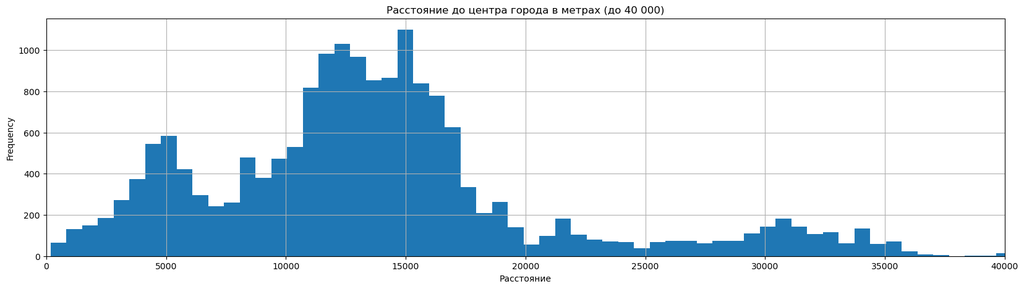

```python
data['cityCenters_nearest'].hist(bins=100, figsize = (20,5))
plt.title("Расстояние до центра города в метрах (до 40 000)")
plt.xlabel("Расстояние")
plt.ylabel("Frequency")
plt.xlim(0,40000)
```

По графику видно, что большинство квартир находится на расстоянии от 10 до 17,5 км от центра, при этом есть всплеск на более близких к центру (4-6 км).

```
count    17771.000000
mean     28829.528276
std      12694.033624
min          0.000000
25%      18490.000000
50%      26825.000000
75%      37406.000000
max      84869.000000
Name: airports_nearest, dtype: float64
```

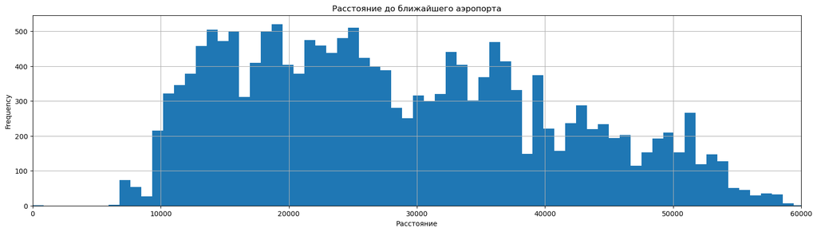

```python
print (data['airports_nearest'].describe())
data['airports_nearest'].hist(bins=100, figsize = (20,5))
plt.xlim(0,60000) #ограничим для рассмотрения
plt.title("Расстояние до ближайшего аэропорта")
plt.xlabel("Расстояние")
plt.ylabel("Frequency")
```

Разброс по расстоянию до аэропорта достаточно большой, большинство квартир в промежутке от 10 до 40 км.

```
count    7837.000000
mean      492.615797
std       342.206244
min         1.000000
25%       288.000000
50%       456.000000
75%       613.000000
max      3190.000000
Name: parks_nearest, dtype: float64
```

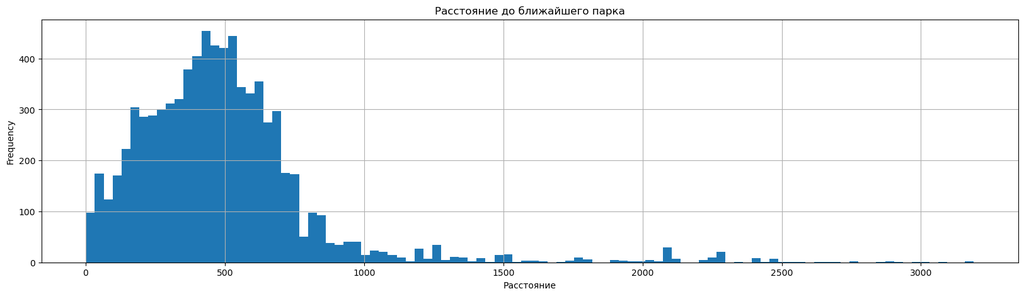

```python
data['parks_nearest'].hist(bins=100, figsize = (20,5))
plt.title("Расстояние до ближайшего парка")
plt.xlabel("Расстояние")
plt.ylabel("Frequency")
data['parks_nearest'].describe()
```

Многие квартиры расположены близко к паркам, большинство на расстоянии до 800 м.

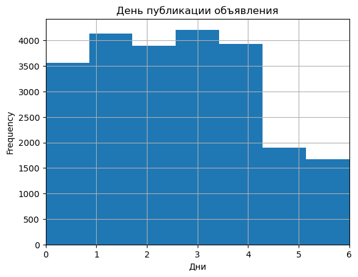

```python
data['published_day'].hist(bins=7)
plt.xlim(0,6)
plt.title("День публикации объявления")
plt.xlabel("Дни")
plt.ylabel("Frequency")
```

Реже всего квартиры публикуют в субботу и воскресенье, самые популярные дни вторник и четверг.

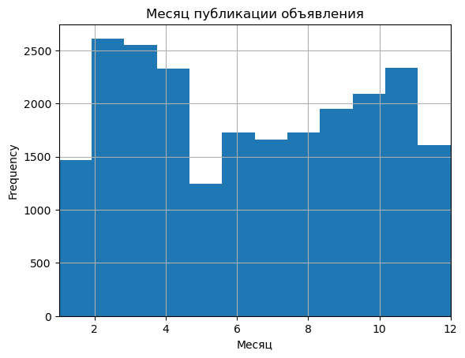

```python
data['published_month'].hist(bins=12)
plt.xlim(1,12)
plt.title("Месяц публикации объявления")
plt.xlabel("Месяц")
plt.ylabel("Frequency")
```

Самые популярные месяцы для размещения объявлений: февраль, март, апрель и ноябрь. Меньше всего объявления публикуют в январе, мае и декабре.

**Изучим, как быстро продавались квартиры:**

```
count    20180.000000
mean       179.284638
std        218.110749
min          1.000000
25%         45.000000
50%         95.000000
75%        229.000000
max       1580.000000
Name: days_exposition, dtype: float64
```

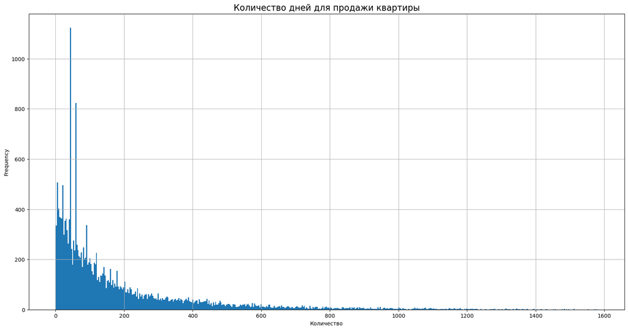

```python
data['days_exposition'].hist(bins=500, figsize = (20,10))
plt.title("Количество дней для продажи квартиры", fontsize=16)
plt.xlabel("Количество")
plt.ylabel("Frequency")
data['days_exposition'].describe()
```

Среднее арифметическое mean = 179

Медиана = 95

Cреднее арифметическое больше почти в 2 раза засчет выбросов. Ограничим период 100 днями, чтобы точнее рассмотреть пиковые значения.

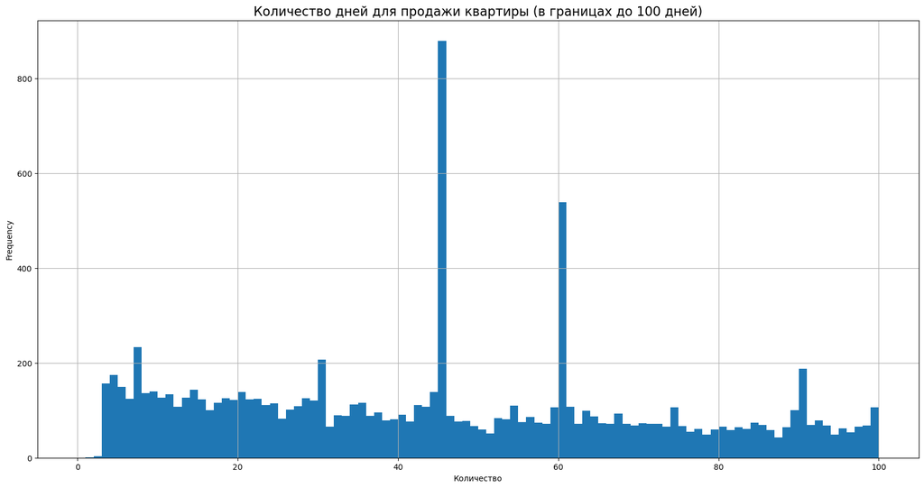

```python
data['days_exposition'].hist(range = (0, 100), bins=100, figsize = (20,10))
plt.title("Количество дней для продажи квартиры (в границах до 100 дней)", fontsize=16)
plt.xlabel("Количество")
plt.ylabel("Frequency")
```

Чаще всего продажа совершается за 45 дней и 60 дней.

**Изучим влияние различных факторов на общую (полную) стоимость объекта.**

Найдем коэффициент корреляции Пирсона, чтобы оценить тесноту взаимосвязи, и посмотрим есть ли линейгая связь между параметрами.

```
                kitchen_area    last_price  living_area  rooms  total_area
ceiling_height
1.00                   10.00  6.000000e+06    32.400000    2.0   55.000000
1.03                     NaN  5.300000e+06    15.500000    1.0   45.000000
1.20                    5.20  1.500000e+06    27.500000    2.0   42.800000
1.40                    9.10  5.600000e+06    32.400000    2.0   56.400000
1.75                    8.34  4.100000e+06    17.400000    1.0   40.000000
...                      ...           ...          ...    ...         ...
5.50                   29.00  3.800000e+07    83.000000    3.0  143.000000
5.80                     NaN  8.200000e+06    68.000000    0.0   71.000000
8.00                    7.65  4.116667e+06    28.433333    2.0   50.333333
8.30                    8.30  5.650000e+06    19.300000    1.0   45.000000
10.00                  11.00  1.500000e+07    14.000000    1.0   25.000000

[164 rows x 5 columns]
              kitchen_area  last_price  living_area     rooms  total_area
kitchen_area      1.000000    0.598957     0.458063  0.322146    0.628800
last_price        0.598957    1.000000     0.686555  0.569662    0.769138
living_area       0.458063    0.686555     1.000000  0.798797    0.937664
rooms             0.322146    0.569662     0.798797  1.000000    0.794317
total_area        0.628800    0.769138     0.937664  0.794317    1.000000
```

```
array([[<Axes: xlabel='kitchen_area', ylabel='kitchen_area'>,
        <Axes: xlabel='last_price', ylabel='kitchen_area'>,
        <Axes: xlabel='living_area', ylabel='kitchen_area'>,
        <Axes: xlabel='rooms', ylabel='kitchen_area'>,
        <Axes: xlabel='total_area', ylabel='kitchen_area'>],
       [<Axes: xlabel='kitchen_area', ylabel='last_price'>,
        <Axes: xlabel='last_price', ylabel='last_price'>,
        <Axes: xlabel='living_area', ylabel='last_price'>,
        <Axes: xlabel='rooms', ylabel='last_price'>,
        <Axes: xlabel='total_area', ylabel='last_price'>],
       [<Axes: xlabel='kitchen_area', ylabel='living_area'>,
        <Axes: xlabel='last_price', ylabel='living_area'>,
        <Axes: xlabel='living_area', ylabel='living_area'>,
        <Axes: xlabel='rooms', ylabel='living_area'>,
        <Axes: xlabel='total_area', ylabel='living_area'>],
       [<Axes: xlabel='kitchen_area', ylabel='rooms'>,
        <Axes: xlabel='last_price', ylabel='rooms'>,
        <Axes: xlabel='living_area', ylabel='rooms'>,
        <Axes: xlabel='rooms', ylabel='rooms'>,
        <Axes: xlabel='total_area', ylabel='rooms'>],
       [<Axes: xlabel='kitchen_area', ylabel='total_area'>,
        <Axes: xlabel='last_price', ylabel='total_area'>,
        <Axes: xlabel='living_area', ylabel='total_area'>,
        <Axes: xlabel='rooms', ylabel='total_area'>,
        <Axes: xlabel='total_area', ylabel='total_area'>]], dtype=object)
```

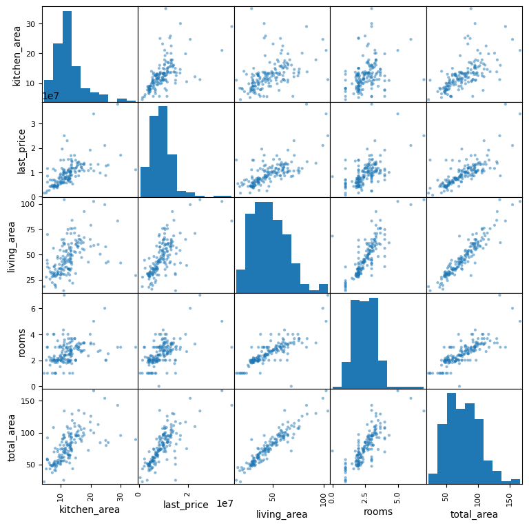

```python
data['last_price'] = data['last_price']*1000000
data_for_corr = data.pivot_table(index='ceiling_height', values=['last_price', 'total_area', 'living_area', 'kitchen_area', 'rooms'])
print (data_for_corr)
print (data_for_corr.corr())
pd.plotting.scatter_matrix(data_for_corr, figsize=(9, 9))
#'floors_type', 'published_day', 'published_month', 'published_year' убрала из сводной
```

Высокая линейная взаимосвязь наблюдается при приближении коэффициента Пирсона к 1 или -1, в изучаемом случае такие значения наблюдаются между:

- living_area и total_area
- living_area и rooms
- last_price и total_area

Посмотрим на зависимость цены на квартиру от общей площади:

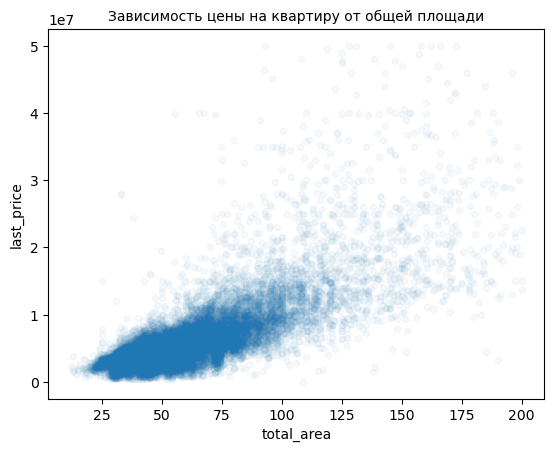

```python
data.plot(y='last_price', x='total_area', kind ='scatter', alpha = 0.04)
plt.title("Зависимость цены на квартиру от общей площади", fontsize=10)
```

Из графика видно, что зависимость для данных параметров линейная.

Посмотрим на зависимость цены на квартиру от жилой площади:

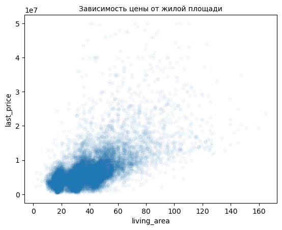

```python
data.plot(y='last_price', x='living_area', kind ='scatter', alpha = 0.04)
plt.title("Зависимость цены от жилой площади", fontsize=10)
```

Из графика видно, что зависимость для данных параметров линейная.

Посмотрим на зависимость цены на квартиру от площади кухни:

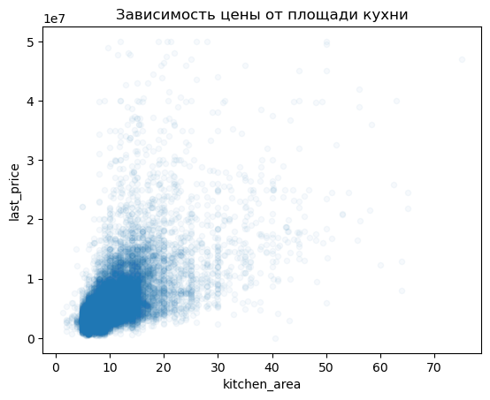

```python
data.plot(y='last_price', x='kitchen_area', kind ='scatter', alpha = 0.04)
plt.title("Зависимость цены от площади кухни")
```

Из графика видно, что зависимость для данных параметров линейная.

Посмотрим на зависимость цены на квартиру от количества комнат:

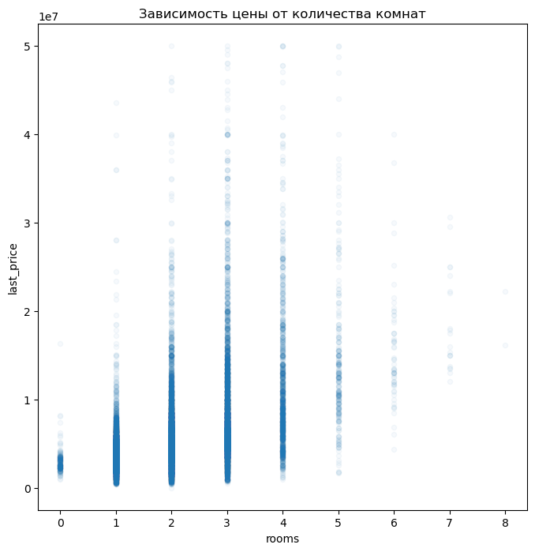

```python
data.plot(y='last_price', x='rooms', kind ='scatter', alpha = 0.04, figsize=(8,8))
plt.title("Зависимость цены от количества комнат")
```

Из графика видно, что количество квартир и цена в данном случае растут линейно начиная с одно- до трёх- комнатных квартир, далее линейный рост теряется и цена помещения не растет в том же темпе при увеличении количества комнат.

Посмотрим на зависимость цены на квартиру от этажа, на котором расположена квартира (первый, последний, другой):

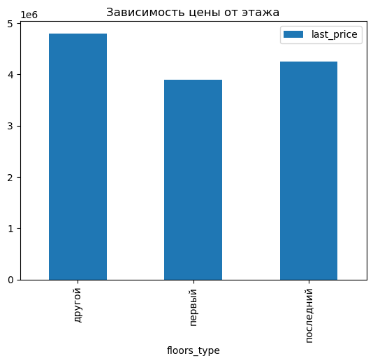

```python
data_for_floors_type = data.pivot_table(index='floors_type', values='last_price', aggfunc='median')
data_for_floors_type.plot.bar()
plt.title("Зависимость цены от этажа")
```

В данном случае видим, что цена на других этажах выше, чем в остальных случаях. На первом этаже цены самые низкие.

Посмотрим на зависимость цены на квартиру от даты размещения (день недели, месяц, год):

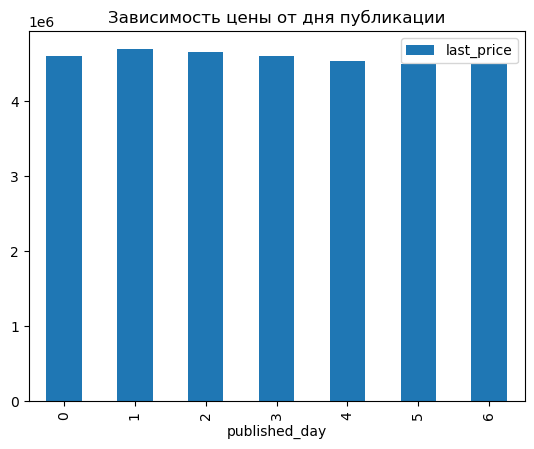

```python
data_for_floors_type = data.pivot_table(index='published_day', values='last_price', aggfunc='median')
data_for_floors_type.plot.bar()
plt.title("Зависимость цены от дня публикации")
```

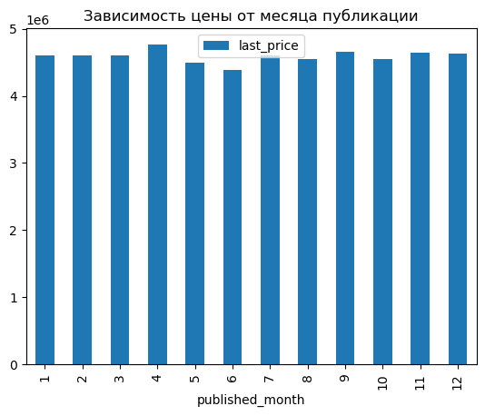

```python
data_for_floors_type = data.pivot_table(index='published_month', values='last_price', aggfunc='median')
data_for_floors_type.plot.bar()
plt.title("Зависимость цены от месяца публикации")
```

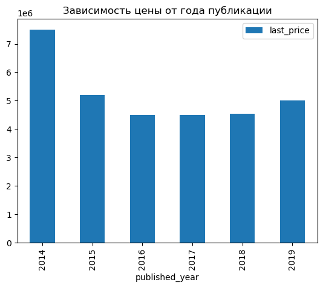

```python
data_for_floors_type = data.pivot_table(index='published_year', values='last_price', aggfunc='median')
data_for_floors_type.plot.bar()
plt.title("Зависимость цены от года публикации")
```

В случаях с днем и месяцем публикации зависимость не прослеживается. В случае с годом видно отличающийся 2014 год, можно предположить, что цена в том году на недвижимость вырастала.

**Посчитаем среднюю цену одного квадратного метра в 10 населённых пунктах с наибольшим числом объявлений.**

Находим локации с наибольшим количеством объявлений

```python
top_for_sale = data['locality_name'].value_counts().head(10)
top_for_sale
```

```
Санкт-Петербург    15387
п. Мурино            552
п. Шушары            439
Всеволожск           398
Пушкин               364
Колпино              337
п. Парголово         326
Гатчина              307
д. Кудрово           299
Выборг               237
Name: locality_name, dtype: int64
```

Находим среднюю цену одного квадратного метра для выбранных локаций

```
                 price_for_m
locality_name
Санкт-Петербург    112271.75
Пушкин             103122.54
д. Кудрово          92473.55
п. Парголово        90332.26
п. Мурино           85629.57
п. Шушары           78551.34
Колпино             75333.30
Гатчина             68746.15
Всеволожск          68654.47
Выборг              58141.91
```

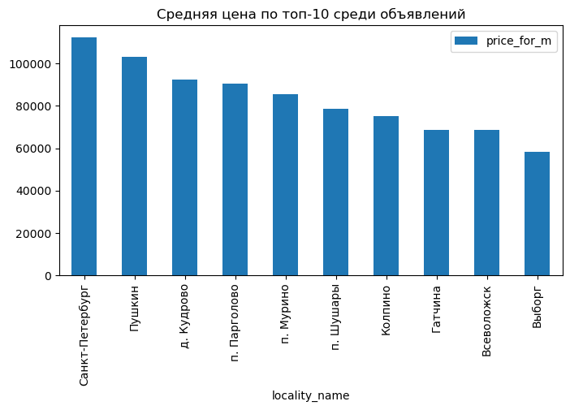

```python
data_price_for_top = data.query('locality_name in @top_for_sale.index').pivot_table(index='locality_name', \
                                                               values=['price_for_m']).sort_values('price_for_m', \
                                                                                                   ascending=False)
print (data_price_for_top.round(2))
data_price_for_top.plot(y= 'price_for_m', kind='bar', figsize = (8, 4))
plt.title("Средняя цена по топ-10 среди объявлений")
```

Населённые пункты с самой высокой ценой за квадратный метр - Санкт-Петербург и Пушкин, с самой низкой стоимостью квадратного метра - Выборг.

**Выделим квартиры в Санкт-Петербурге и вычислим среднюю цену каждого километра.**

```
                          last_price
cityCenters_nearest_km
0.0                     2.057746e+07
1.0                     1.233860e+07
2.0                     1.181925e+07
3.0                     1.006897e+07
4.0                     1.072291e+07
5.0                     1.125030e+07
6.0                     1.117712e+07
7.0                     1.126883e+07
8.0                     8.928063e+06
9.0                     6.909052e+06
10.0                    6.364743e+06
11.0                    6.100417e+06
12.0                    5.783514e+06
13.0                    6.050973e+06
14.0                    5.582708e+06
15.0                    5.804782e+06
16.0                    5.364011e+06
17.0                    5.210039e+06
18.0                    4.868169e+06
19.0                    5.051410e+06
20.0                    5.951465e+06
21.0                    5.493469e+06
22.0                    5.415524e+06
23.0                    4.689843e+06
24.0                    3.854430e+06
25.0                    4.052840e+06
26.0                    4.014287e+06
27.0                    8.300000e+06
28.0                    5.026429e+06
29.0                    4.236667e+06
         last_price
count  3.000000e+01
mean   7.409209e+06
std    3.643489e+06
min    3.854430e+06
25%    5.091067e+06
50%    5.878123e+06
75%    9.783747e+06
max    2.057746e+07
```

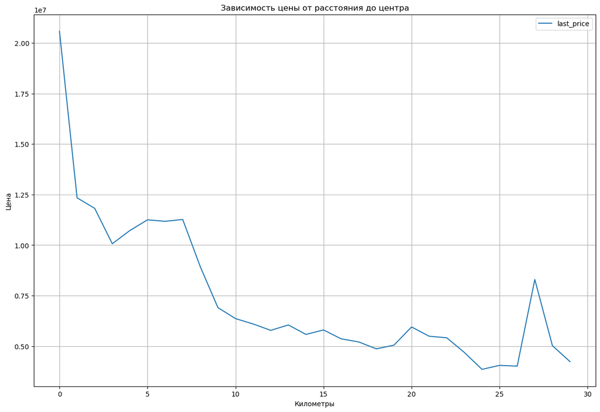

```python
data_local_spb = data.query('locality_name == "Санкт-Петербург"').pivot_table(index='cityCenters_nearest_km', values=['last_price'])
print (data_local_spb)
print (data_local_spb.describe())
data_local_spb.plot(grid=True, figsize=(15, 10))
plt.title("Зависимость цены от расстояния до центра")
plt.xlabel("Километры")
plt.ylabel("Цена")
```

По графику видно, что цена на минимальном расстоянии от центра - самая высокая. От 0 до 3 км идет сильный и резкий спад, далее рост с пиком на 7,5 км, после 7,5 км вновь падение и значительный подъём на 27 км с дальнейшим падением. Можно предположить, что в пиковых значениях на 7,5 и 27 км находятся в живописные, возможно, эксклюзивные локации с достопримечательностями или очень хорошими видами, или в экологически чистых районах.

### Общий вывод

**В результате проведенного анализа были получены следующие результаты:**

1. Типичный объект недвижимости, размещенный на сайте для продажи, соответствует следующим критериям:
- площадь квартиры от 40 до 50 м;
- жилая площадь от 13 до 47 м;
- площадь кухни от 5 до 13 м;
- стоимость от 3,4 до 6,8 млн руб;
- количество комнат от 1 до 3;
- высота потолков от 2 до 2,8 м;
- расположены на нижних этажах (до 5 включительно), при этом не первый и не последний этаж;
- большинство квартир расположено в домах невысокой этажности (от 5 до 9 этажей);
- находятся на расстоянии от 10 до 17,5 км от центра;
- находятся на расстоянии от 10 до 40 км от аэропорта;
- в пешей доступности от парков - до 800 м.
1. Публикация объявлений чаще всего происходит во вторник и четверг. Самые популярные месяцы для размещения объявлений: февраль, март, апрель и ноябрь.
2. Наибольшее влияние на стоимость объекта оказывает его площадь. Так же цена растет пропорционально количеству комнат для 1-3-ёх комнатных квартир.
3. Населённые пункты с самой высокой ценой за квадратный метр среди топ 10 по количеству объявлений - Санкт-Петербург и Пушкин, с самой низкой стоимостью квадратного метра - Выборг.
4. При изучении влияния удаленности от центра города на цену недвижимости в Санкт-Петербурге выявлено, что цена на минимальном расстоянии от центра - самая высокая. От 0 до 3 км идет сильный и резкий спад, далее рост с пиком на 7,5 км.